# Ortogonalidade e Mínimos quadráticos

Diogo Bolzan - 00580408

2024-01-20

[figure not shown]

[figure not shown]

# 1 - Produto Interno, Comprimento e Ortogonalidade

## 1.1 - O Produto Interno:

$\text{Produto Interno tem por objetivo verificar se dois vetores são ortogonais entre si (ou seja, tem 90 graus), para serem ortogonais o produto interno deve dar zero}$

$$\text{Só sera ortogonal se e somente
se: }<u \cdot v> = (v1 \times u1 + v2 \times u2 + v3\times u3...)
= 0.$$

## 1.2 - O comprimento de um vetor

$\text{Como em cálculo, quando queremos encontrar o comprimento de um vetor, cálculamos a norma dele:}$

$$||u|| =
\sqrt{u_1^{2}+u_2^{2}+u_3^{3}...}$$

$\text{Se o vetor tiver comprimento 1, chamamos de vetor unitário, para transformar qualquer vetor em unitário basta fazer:}$

$$\text{Vetor unitário = }\frac{1}{||u||}$$

## 1.3 - A distância entre vetores

$\text{A distância é denotada por dist(u,v) e cálculada por:}$

$$dist(u,v) = ||u-v||$$

## 1.4 - Vetores Ortogonais

$\text{Dois vetores só são ortogonais se e somente se o produto interno da zero, assim um conjunto ortogonal é um conjunto de vetores que o produto interno entre eles é zero}$

$\text{Verifique se }Y = {(1, −1, 2, 0),(−4, 2, 3, −3),(−1, 1, 1, 3)} ⊆ R^{4} \text{ é um conjunto ortogonal}$
$$\text{Resposta: Aqui
temos 3 vetores que fazem parte do } R^{4} \text{ temos, v1,v2 e v3.
Para verificar se é um conjunto ortogonal, }$$
$$\text{fazemos: }v1 \cdot v2 \text{ e verificamos
se da zero}$$
$$\text{em seguida: }v2
\cdot v3 \text{ e verificamos se da zero}$$
$$\text{por fim: }v1 \cdot v3 \text{ e verificamos
se da zero}$$

## 1.5 - Complemento Ortogonal

$\text{Para entender complemento Ortogonal é fundamental entender a noção de espaços e subespaços.}$ $\text{Imagine uma caixa e dentro desta caixa há outras duas menores: }$

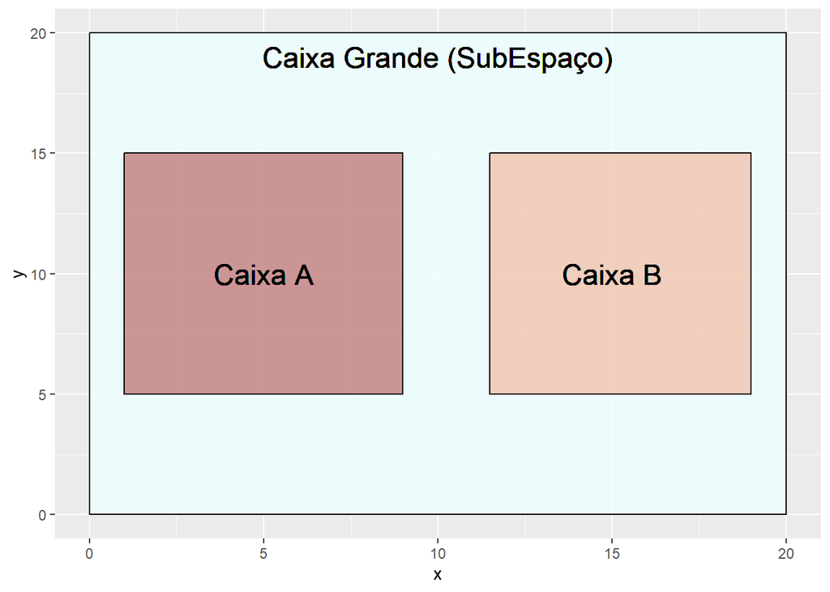

$\text{A caixa grande é um subespaço de } R^{n}\text{ enquanto as caixas menores são subespaços da caixa maior.}$

$\text{Quando pedir para cálcular um complemento ortogonal de um subespaço gerado por algum }Span,\text{(geralmente é dado os valores do Span)}$ $\text{devemos pensar que a caixa A é esse subespaço gerado e queremos encontrar qual a equação que gera a caixa B.}$

$\text{De maneira simples é isso, porém a caixa B tem que ter os valores dos vetores dela todos ortogonais aos valores dos vetores da caixa A, como assim?}$ $\text{Imagine que a Caixa A contém todos os valores que dão origem ao eixo X, logo } Span\{(1,0)\} = \{(a,0): a \in R\}$

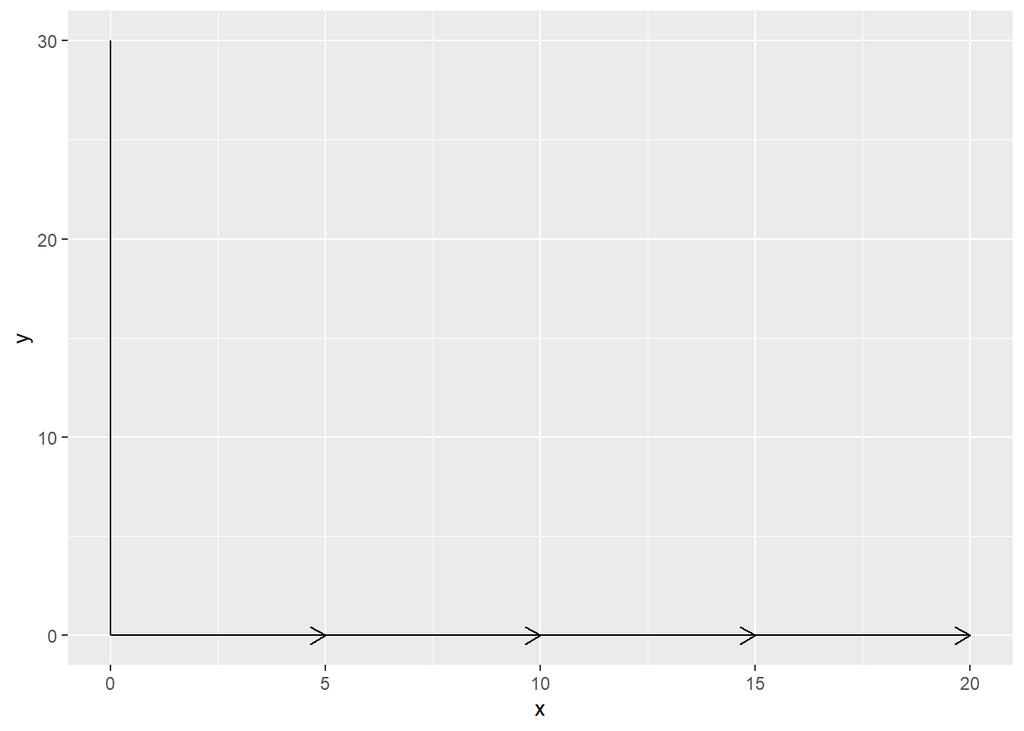

$\text{O complemento Ortognal é todos os vetores do eixo Y pois TODOS eles são ortogonais a TODOS do eixo X:}$

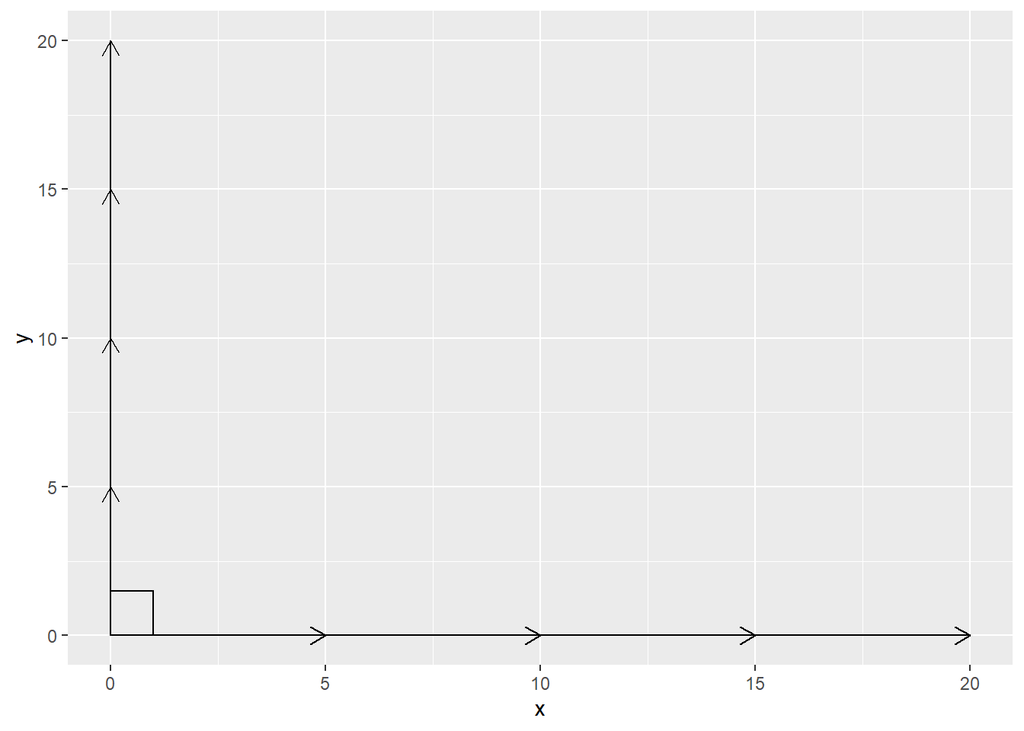

O metodo para encontrar um complemento ortogonal é:

1. Será dado um subespaço como V = Span{(1,2,3),(2,3,4)}
2. Encotrar conjunto de equações que fazem parte do Span:

(1,2,3) = x + 2y + 3z

(2,3,4) = 2x + 3y + 4z

3. Resolva o sistema Homogêneo:

x + 2y + 3z = 0

2x + 3y + 4z = 0

4. Simplifique o resultado:

x = z

y = -2z

logo: (z,-2z,z) = z(1,-2,1) = Span{(1,-2,1)} Perceba que a dimensão do span é 1 enquanto a do V é 2, portando a dimensão em que ambos estão incluídos (Caixa Grande) = 2 + 1 = 3.

# 2 - Projeções Ortogonais

## 2.1 - Vetor B-Coordenada

$\text{Seja W um subespaço do }R^{n}\text{ e se } \{u_1,u_2,...\} \text{ é uma base ortogonal para W,} \text{ para encontrar a projeção de um vetor sobre o outro, temos que: }$
$$y = \frac{y \cdot u_1}{u_1 \cdot u_1} , ...
, \frac{y \cdot u_p}{u_p \cdot u_p}$$

# 3 - O Processo de Gram - Schmidt

## 3.1 - Algoritmo para Gram - Schmidt

$\text{Esse processo é usado para encontrar uma base ortogonal para qualquer subespaço de }R^{n}$

$\text{Desde já, tenha cuidado para não confundir com a fórmula usada em 2.1, já que são muito semelhantes. O problema anterior trata de encontrar um vetor B-Coordenada, o de agora é de achar uma base ortogonal para um Subespaço!!}$

$$\text{Dada uma base }\{x_1,x_2,... \}
\text{ para um subespaço W, defina: }$$
$$w_1 = x_1$$
$$w_2 = x_2 - \frac{x_2 \cdot w_1}{w_1 \cdot
w_1}$$
$$w_3 = x_3 - \frac{x_3 \cdot
w_1}{w_1 \cdot w_1}w_1 - \frac{x_3 \cdot w_2}{w_2 \cdot w_2}w_2$$
$$\cdot \cdot \cdot w_p = x_p -
\frac{x_p \cdot w_1}{w_1 \cdot w_1}w_1-\frac{x_p \cdot w_2}{w_2 \cdot
w_2}w_2...-\frac{x_p \cdot w_{p-1}}{w_{p-1} \cdot w_{p-1}}w_{p-1}$$
$\text{Então }\{v_1,v_2...v_n\} \text{ é uma base ortogonal para W. Além disso o }Span\{v_1,v_2...v_k\} \text{ e } Span\{x_1,x_2...x_k\} \text{ são iguais para }1 \leq k \leq p.$

$\text{Exemplo Lista 7 ex. 8: $ $Considere os vetores v1 = (0, 4, 2), v2 = (5, 6, −7) e v3 = (4, −1, 2). A letra a pede para mostrar que é uma base, vamos assumir que já foi feito isso e ir para letra b.}$ $ $

## 3.2 - Bases Ortonormais

$\text{Para construir uma base Ortonormal basta ter a base ortogonal e fazer:}$
$$\text{dado uma base Ortogonal
}\{v_1,v_2,...v_n\}: u_1 = \frac{1}{||v_1||}v_1, u_2 =
\frac{1}{||v_2||}v_2...$$

# 4 - Problemas de Mínimos Quadráticos

$\text{O problema é semelhante a achar uma reta de regressão linear. Imagine que é um pesquisador e encontrou os seguintes dados:}$

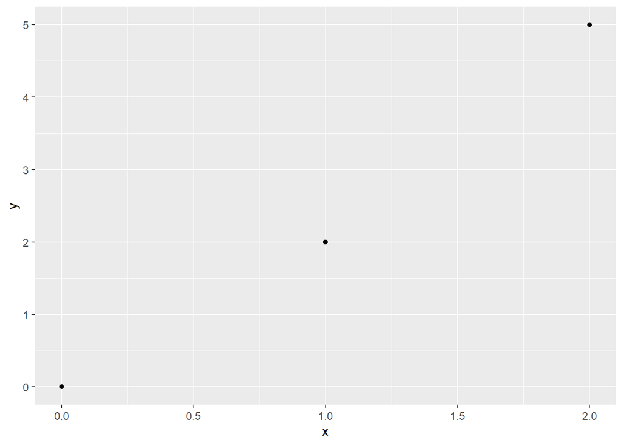

$\text{O problema de minimizar é descobrir qual a reta que mais se aproxíma para explicar a dispersão dos dados.}$

$\text{Temos os seguintes dados:}$

$$\left(\begin{array}{cc}
x & y\\
0 & 0\\
1 & 2\\
2 & 5\\
\end{array}\right)$$

$\text{Ou seja:}$

$$\left(\begin{array}{cc}
y(0) = a+b.0 = 0\\
y(1) = a+b.1 = 2\\
y(2) = a+b.2 = 5\\
\end{array}\right)$$
$\text{Dito isso de outra forma, precisamos resolver o sistema:}$

$$\begin{cases}
1a + 0b = 0\\
1a + 1b = 2\\
1a + 2b = 5\\
\end{cases}$$
$$A = \left(\begin{array}{cc}
1 & 0 \\
1 & 1\\
1 & 2\\
\end{array}\right)b = \left(\begin{array}{cc}
0 \\
2 \\
5 \\
\end{array}\right)$$

$\text{Logo, basta resolver esse sistema, porém segundo Definição 7.4.2, usada pelo professor}$ $\text{iremos chamar de solução para mínimos quadrados toda solução do sistema de equações lineares } Ax = proj_{col A}b$

$$\text{Vamos usar a fórmual: }proj_{col
A}b = (A^{t}A)x=A^{t}b$$
$$A^{t}A=
\left(\begin{array}{cc}
1 & 1 & 1 \\
0 & 1 & 2 \\
\end{array}\right) \left(\begin{array}{cc}
1 & 0 \\
1 & 1 \\
1 & 2 \\
\end{array}\right) = \left(\begin{array}{cc}
3 & 3 \\
3 & 5 \\
\end{array}\right)$$
$\text{Lembre-se para cálcular essa multiplicação faça todos elementos da primeira linha da primeira matriz vezes a primeira coluna da segunda matriz...}$

$$A^{t}b= \left(\begin{array}{cc}
1 & 1 & 1 \\
0 & 1 & 2 \\
\end{array}\right) \left(\begin{array}{cc}
0 \\
2 \\
5 \\
\end{array}\right) = \left(\begin{array}{cc}
7 \\
12 \\
\end{array}\right)$$

$\text{Assim temos a seguinte fórmula que explica os dados: }y(x) = \frac{5x}{2}-\frac{1}{6}$

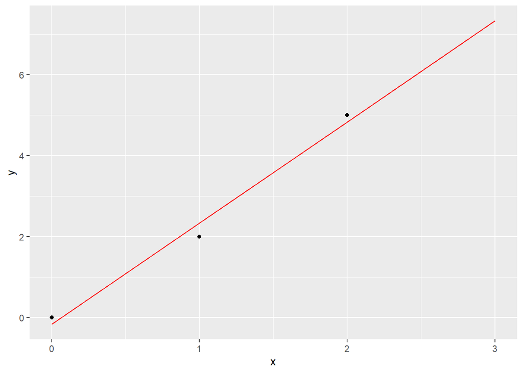

$\text{Exemplo com equação Quadrática: }$

$\text{Ache a equação que mais se aproxíme de descrever os dados:}$

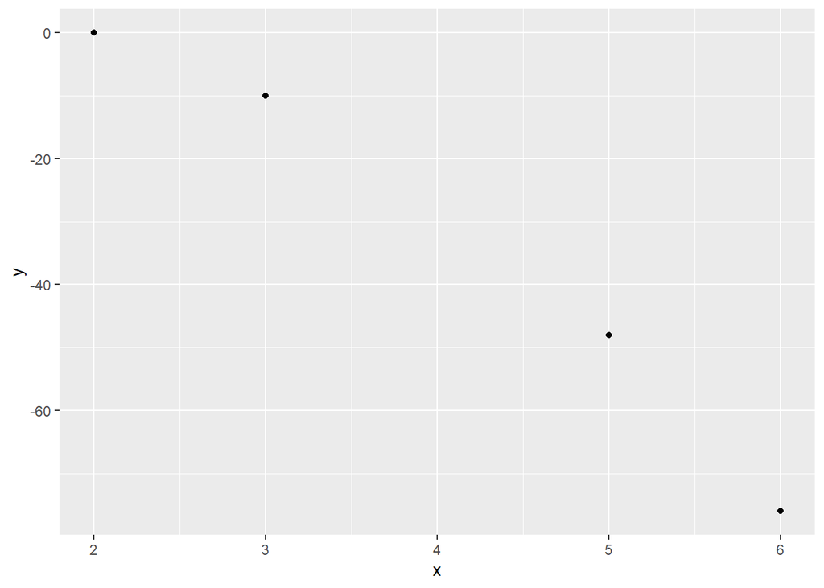

$\text{Portando a matriz que representa os dados é: }$
$$\text{Logo temos que:
}\left(\begin{array}{cc}
x & y \\
2 & 0 \\
3 & -10 \\
5 & -48 \\
6 & -76 \\
\end{array}\right)$$
$ $ $\text{sejam pontos do gráfico da função polinomial definida pelo polinômio p(t) = c + bt + }at^{2}\text{. Equivalentemente, queremos uma solução de mínimos quadrados do sistema de equações:}$

$$\begin{cases}
y(x) = 4a + 2b + c = 0 \\
y(x) = 9a + 3b + a = -10 \\
y(x) = 25a + 5b + c = -48\\
y(x) = 36a + 6b + c = -76 \\
\end{cases}$$

$\text{Escrevendo em forma de matriz:}$
$$\left(\begin{array}{cc}
4 & 2 & 1 \\
9 & 3 & 1 \\
25 & 5 & 1 \\
36 & 6 & 1 \\
\end{array}\right)
\left(\begin{array}{cc}
a \\
b \\
c \\
\end{array}\right) =
\left(\begin{array}{cc}
0 \\
-10 \\
-48 \\
-76 \\
\end{array}\right)$$

$\text{Usando a fórmula para cálcular a equação que mais se aproxíma: }proj_{col A}b = (A^{t}A)x=A^{t}b$

$$(A^{t}A) = \left(\begin{array}{cc}
4 & 9 & 25 & 36 \\
2 & 3 & 5 & 6 \\
1 & 1 & 1 & 1 \\
\end{array}\right) \left(\begin{array}{cc}
4 & 2 & 1 \\
9 & 3 & 1 \\
25 & 5 & 1 \\
36 & 6 & 1 \\
\end{array}\right) = \left(\begin{array}{cc}
2018 & 376 & 74 \\
376 & 74 & 16 \\
74 & 16 & 4\\
\end{array}\right)$$

$$A^{t}b = \left(\begin{array}{cc}
4 & 9 & 25 & 36 \\
2 & 3 & 5 & 6 \\
1 & 1 & 1 & 1 \\
\end{array}\right)
\left(\begin{array}{cc}
0 \\
-10 \\
-48 \\
-76 \\
\end{array}\right) =
\left(\begin{array}{cc}
-4026\\
-726 \\
-134 \\
\end{array}\right)$$

$$Logo = \left(\begin{array}{cc}
2018 & 376 & 74 \\
376 & 74 & 16 \\
74 & 16 & 4\\
\end{array}\right)
\left(\begin{array}{cc}
x \\
y \\
z \\
\end{array}\right) =
\left(\begin{array}{cc}
-4026\\
-726 \\
-134 \\
\end{array}\right) =
\left(\begin{array}{ccc|c}
1 & 0 & 0 & -3\\
0 & 1 & 0 & 5\\
0 & 0 & 1 & 2\\
\end{array}\right)$$

$\text{Assim temos que a = -3, b= 5 e c = 2, formando a seguinte equação:}$
$$\text{p(t) = c + bt + }at^{2} = 2 + 5t -
3t^2$$

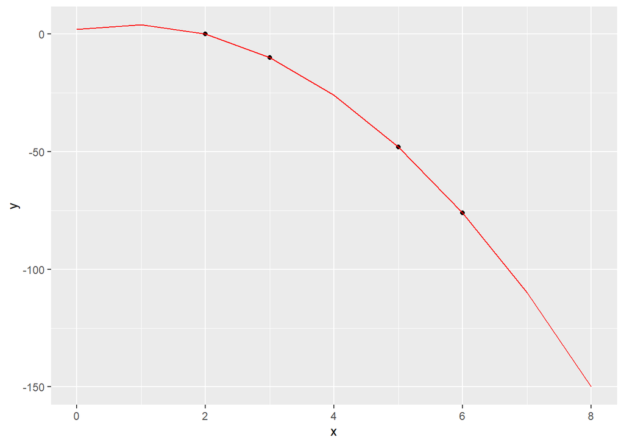

## Erro de mínimos Quadrados

$\text{Atravez do cálculo do erro de mínimo quadrado podemos ver se a matriz é compatível ou não: }$
$$\text{Erro de Mínimo = ||b - Ax||}$$
$\text{onde b é matriz com os valores de y e A é a matriz A e x o resultado que é usado para construir a reta}$

$\text{Perceba que o x é o valor que você encontra para fazer as retas (a,b,c)}$

$\text{Vamos cálcular o erro para o exercício anterior:}$

$$||b - Ax|| =
\left(\begin{array}{ccc|c}
0\\
-10\\
-48\\
-76 \\
\end{array}\right) -
\left(\begin{array}{cc}
4 & 2 & 1 \\
9 & 3 & 1 \\
25 & 5 & 1 \\
36 & 6 & 1 \\
\end{array}\right)
\left(\begin{array}{ccc|c}
-3\\
5\\
2\\
\end{array}\right) = \left(\begin{array}{ccc|c}
0\\
-10\\
-48\\
-76 \\
\end{array}\right) -
\left(\begin{array}{ccc|c}
0\\
-10\\
-48\\
-76 \\
\end{array}\right) = 0$$

$\text{e, consequentemente, o erro de mínimos quadrados é nulo, pois }Ax = b, \text{ou seja } ||Ax = b|| = 0. \text{ E portanto, o gráfico da função polinomial } f(t) = 2 + 5t − 3t^{2} \text{ passa exatamente sobre os pontos dados}$